# Tidy Data and Summarization

## Gather (from wide to long)

Then gather it back up into the original

```r
wine_long <- wine_wide %>%
  gather("variety", "points", 2:5)

wine_long
```

```
## # A tibble: 128 x 3
## # Groups:   country [32]
##    country   variety            points
##    <chr>     <chr>               <dbl>
##  1 Argentina Cabernet Sauvignon   86.0
##  2 Australia Cabernet Sauvignon   89.3
##  3 Austria   Cabernet Sauvignon   87.4
##  4 Brazil    Cabernet Sauvignon   83
##  5 Bulgaria  Cabernet Sauvignon   87.8
##  6 Canada    Cabernet Sauvignon   90
##  7 Chile     Cabernet Sauvignon   86.7
##  8 Croatia   Cabernet Sauvignon   NA
##  9 England   Cabernet Sauvignon   NA
## 10 France    Cabernet Sauvignon   85.4
## # … with 118 more rows
```

Why are there more rows than the original?

## Data summarization

## Basics

Data summarization involves

- Describing data with numerical summaries
- Visualizing data with graphical summaries

…however, there is a difference in how we describe the data depending on whether it is

- discrete, or
- continuous

## Describing discrete data

```r
wine %>%
  count(country)
```

```
## # A tibble: 44 x 2
##    country                    n
##    <chr>                  <int>
##  1 Argentina               3800
##  2 Armenia                    2
##  3 Australia               2329
##  4 Austria                 3345
##  5 Bosnia and Herzegovina     2
##  6 Brazil                    52
##  7 Bulgaria                 141
##  8 Canada                   257
##  9 Chile                   4472
## 10 China                      1
## # … with 34 more rows
```

## A ‘tidy’ pivot table

```r
wine %>%
  count(country, variety)
```

```
## # A tibble: 1,644 x 3
##    country   variety                               n
##    <chr>     <chr>                             <int>
##  1 Argentina Barbera                               1
##  2 Argentina Bonarda                             105
##  3 Argentina Bordeaux-style Red Blend             89
##  4 Argentina Bordeaux-style White Blend            1
##  5 Argentina Cabernet Blend                        8
##  6 Argentina Cabernet Franc                       64
##  7 Argentina Cabernet Franc-Cabernet Sauvignon     3
##  8 Argentina Cabernet Franc-Malbec                 4
##  9 Argentina Cabernet Sauvignon                  540
## 10 Argentina Cabernet Sauvignon-Cabernet Franc     1
## # … with 1,634 more rows
```

## Exercise

### Use filter and count to figure out which country has more Chardonnay, France or the US.

## Solution

```r
wine %>%
  filter(country=="France" | country=="US") %>%
  filter(variety=="Chardonnay") %>%
  count(country)
```

```
## # A tibble: 2 x 2
##   country     n
##   <chr>   <int>
## 1 France   2808
## 2 US       6801
```

## Visualization basics

### ggplot2 requires the following:

1. Data – Data to visualize.
2. Aesthetics – Mapping graphical elements to data.
3. Geometries – Or “geom,” the graphic representing the data.

## Visualizing discrete data

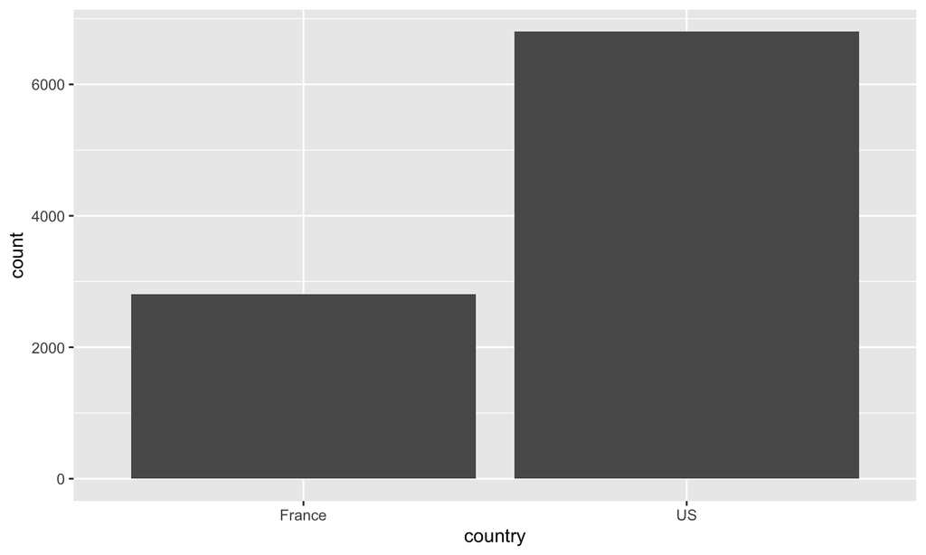

```r
wine %>%
  filter(country=="France" | country=="US") %>%
  filter(variety=="Chardonnay") %>%
  ggplot(aes(x=country)) +
    geom_bar()
```

## Let’s try a more complicated count

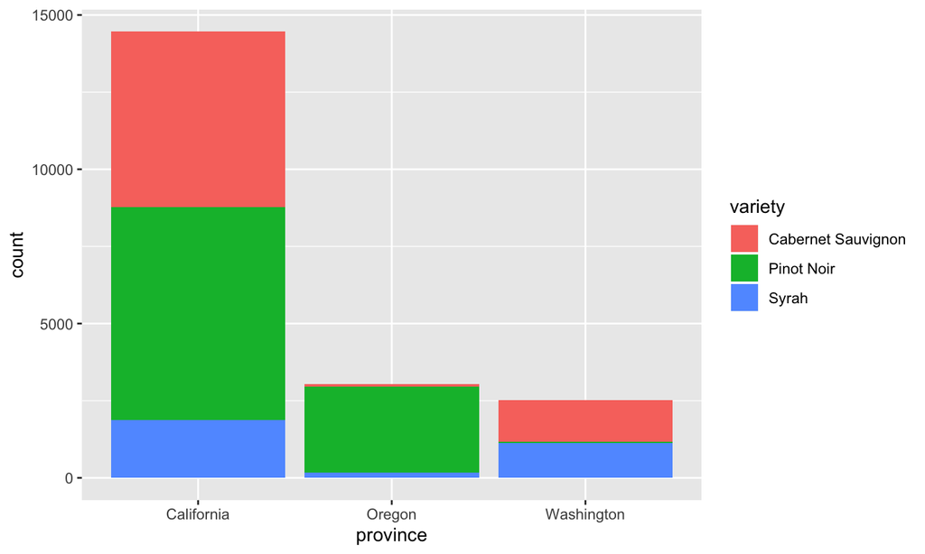

```r
wine %>%
  filter(province=="Washington" | province=="Oregon" | province=="California") %>%
  filter(variety=="Cabernet Sauvignon" | variety =="Syrah" | variety=="Pinot Noir") %>%
  ggplot(aes(x=province, fill=variety)) +
    geom_bar()
```

## Exercise

### Create a stacked bar graph that shows

1. A count of wines
2. with greater than 97 points
3. from California, Oregon and Washington
4. stacked by variety

## Solution

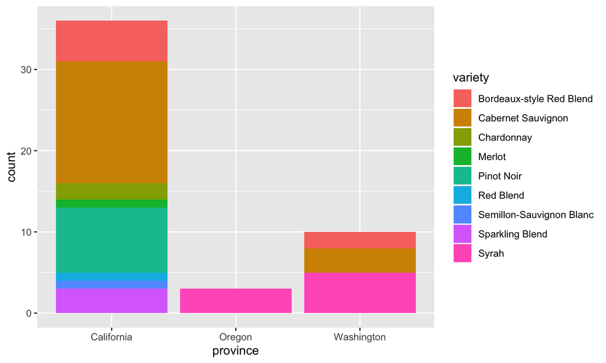

```r
wine %>%
  filter(points >= 98) %>%
  filter(province=="Washington" | province=="Oregon" | province=="California") %>%
  ggplot(aes(x=province, fill=variety)) +
    geom_bar()
```

## Describing continuous data

You can use the summarize function for calculating things like mean, median, variance, min/max, etc.

```r
wine %>%
  summarize(avg_points=mean(points))
```

```
## # A tibble: 1 x 1
##   avg_points
##        <dbl>
## 1       88.4
```

## Visualizing a continuous distribution

Of course that’s not very exciting. Let’s graph the distribution of points.

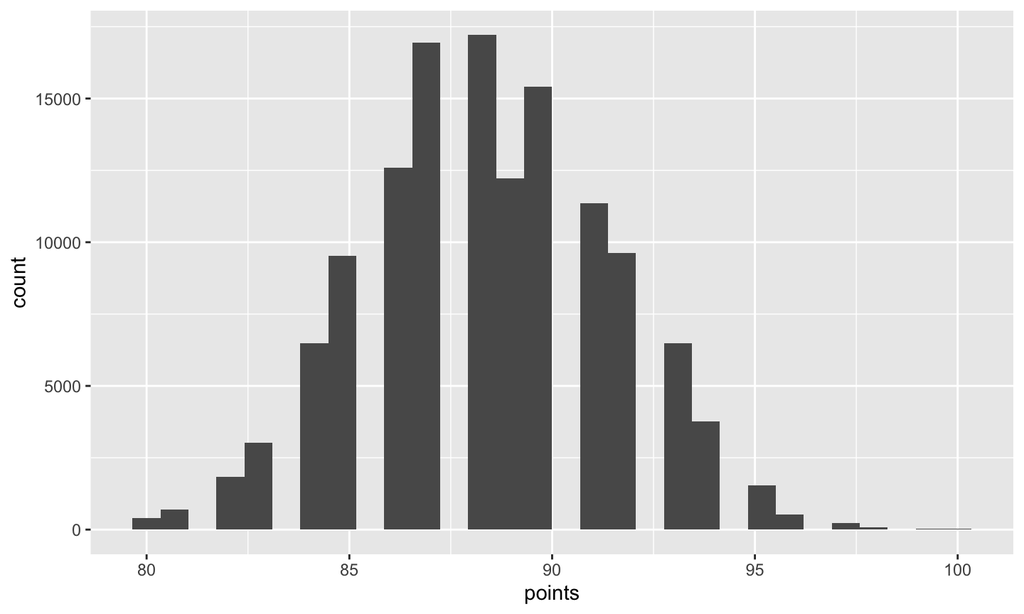

```r
wine %>%
  ggplot(aes(x=points)) +
    geom_histogram()
```

## Visualizing two continuous variables

…or the relationship between points and price

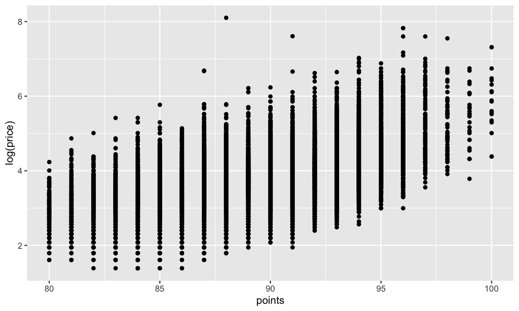

```r
wine %>%
  ggplot(aes(x=points, y=log(price))) +
  geom_point()
```

## Combining discrete and continuous variables

Somtimes, we want to summarize by a category

```r
wine %>%
  filter(country=="US") %>%
  filter(!is.na(price)) %>%
  group_by(province) %>%
  summarize(
    count = n(),
    average_points=mean(points),
    average_price=mean(price)) %>%
  filter(count>100) %>%
  arrange(desc(average_points))
```

```
## # A tibble: 7 x 4
##   province   count average_points average_price
##   <chr>      <int>          <dbl>         <dbl>
## 1 Oregon      5359           89.1          36.5
## 2 Washington  8583           89.0          32.4
## 3 California 36104           88.6          39.0
## 4 New York    2676           87.2          22.8
## 5 Idaho        190           86.6          20.8
## 6 Michigan     111           86.2          32.4
## 7 Virginia     770           85.6          27.0
```

*Note:* the count() function used previously is just a wrapper around summarize(count=n())

## Exercise

### Create a tibble that shows

1. US wines
2. grouped by province and variety,
3. summarized on count and max price
4. with a count greater than 100
5. sorted by count descending

*Hint:* don’t forget to filter out the ‘NA’ prices

## Solution

```r
wine %>%
  filter(country=="US") %>%
  filter(!is.na(price)) %>%
  group_by(province, variety) %>%
  summarize(
    count = n(),
    max_price=max(price)) %>%
  filter(count>100) %>%
  arrange(desc(count))
```

```
## # A tibble: 64 x 4
## # Groups:   province [5]
##    province   variety            count max_price
##    <chr>      <chr>              <int>     <dbl>
##  1 California Pinot Noir          6875       155
##  2 California Cabernet Sauvignon  5668       625
##  3 California Chardonnay          5157      2013
##  4 Oregon     Pinot Noir          2779       275
##  5 California Zinfandel           2633       100
##  6 California Syrah               1862       750
##  7 California Sauvignon Blanc     1801        75
##  8 California Red Blend           1791       290
##  9 California Merlot              1390       200
## 10 Washington Cabernet Sauvignon  1356       160
## # … with 54 more rows
```

## Visualizing discrete and continuous

Sometimes we want to visualize a continuous variable by category as a boxplot

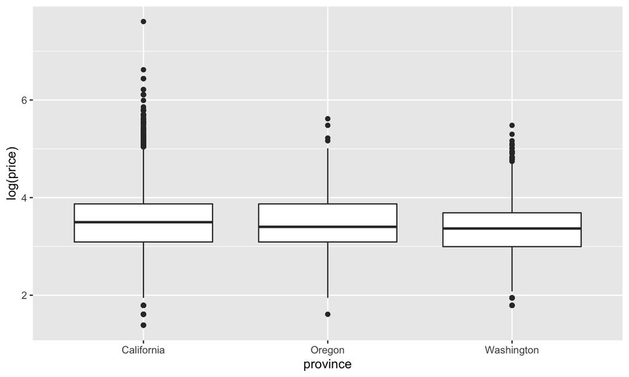

```r
wine %>%
  filter(province=="California" | province=="Oregon" | province=="Washington") %>%
  ggplot(aes(x=province, y=log(price))) +
    geom_boxplot()
```

## Visualizing discrete and continuous (cont’d)

…or as a density function

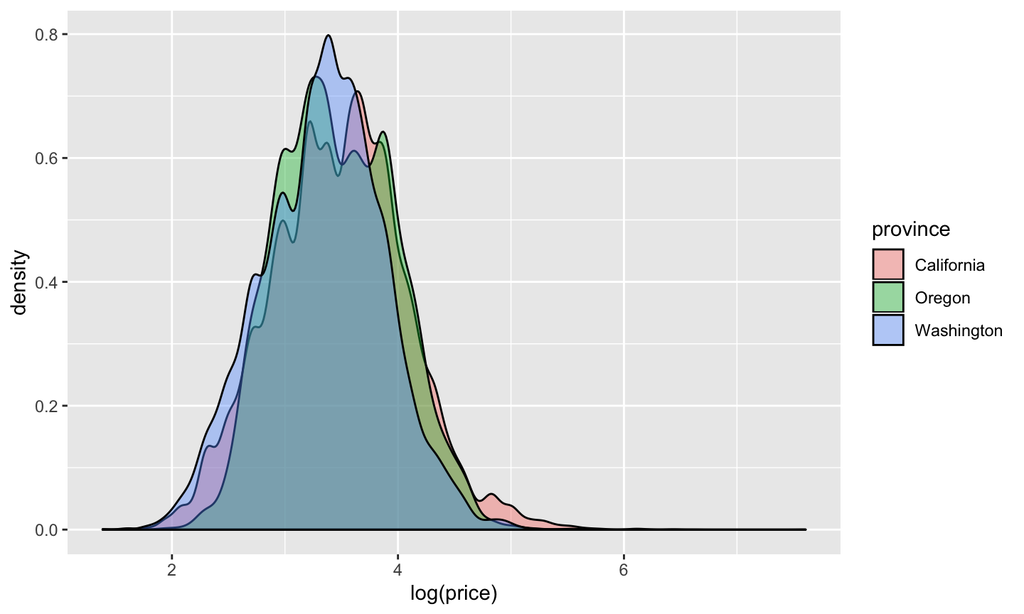

```r
wine %>%
  filter(province=="California" | province=="Oregon" | province=="Washington") %>%
  ggplot(aes(x=log(price), fill=province)) +
    geom_density(alpha = 0.4)
```

## Long exercise

### Gather in groups of 3ish and…

1. Choose a driver
2. Choose a country
3. Summarize the wine data from that country (numerically and visually)
4. Write comments about what you find in the markdown
5. Make sure “echo=FALSE” on your chunks
6. Knit to HTML and email me the file.